# CIA-3: Descriptive Analysis of Air Quality Dataset

Zishan Mallick 24221055

# A. Problem Statement and Objectives

### Problem Area:

Air pollution is a significant environmental issue. Understanding metrics like ozone concentration and its relationship with temperature, wind, and solar radiation can help in environmental policy and planning.

### Objective:

To perform a descriptive analysis of the **airquality** dataset using R, identify patterns, and interpret results with social and ethical context.

# B. Descriptive Analytics and Insights

```r
# Load the airquality dataset
data(airquality)

# Add Month as a factor for better plotting
airquality <- airquality %>%
  mutate(Month_Factor = factor(Month, labels = month.abb[5:9]))
```

## Descriptive Statistics

```r
# Summary stats for numeric variables
desc_stats <- airquality %>%
  summarise(across(where(is.numeric), list(mean = ~round(mean(.x, na.rm = TRUE), 2),
                                           sd = ~round(sd(.x, na.rm = TRUE), 2))))
kable(desc_stats, caption = "Descriptive Statistics of Air Quality Variables") %>%
  kable_styling()
```

Descriptive Statistics of Air Quality Variables

| Ozone_mean | Ozone_sd | Solar.R_mean | Solar.R_sd | Wind_mean | Wind_sd | Temp_mean | Temp_sd | Month_mean | Month_sd | Day_mean | Day_sd |
| --- | --- | --- | --- | --- | --- | --- | --- | --- | --- | --- | --- |
| 42.13 | 32.99 | 185.93 | 90.06 | 9.96 | 3.52 | 77.88 | 9.47 | 6.99 | 1.42 | 15.8 | 8.86 |

## Histogram of Ozone Levels

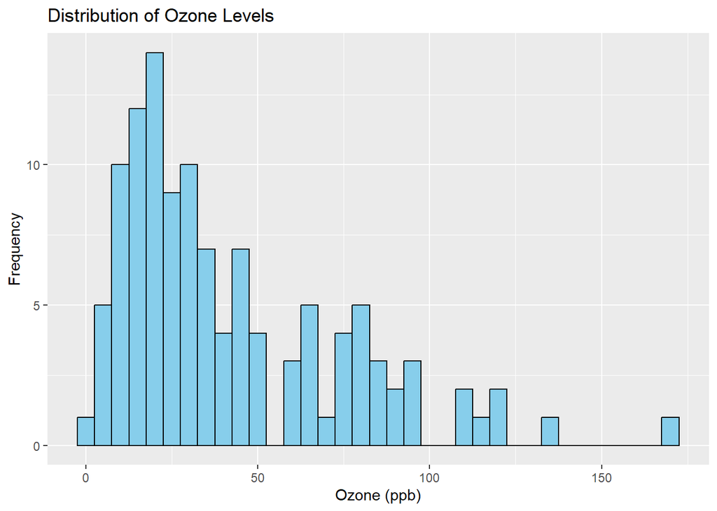

```r
# Plot histogram of Ozone levels
ggplot(airquality, aes(x = Ozone)) +
  geom_histogram(binwidth = 5, fill = "skyblue", color = "black", na.rm = TRUE) +
  labs(title = "Distribution of Ozone Levels", x = "Ozone (ppb)", y = "Frequency")
```

## Scatter Plot: Ozone vs Temperature

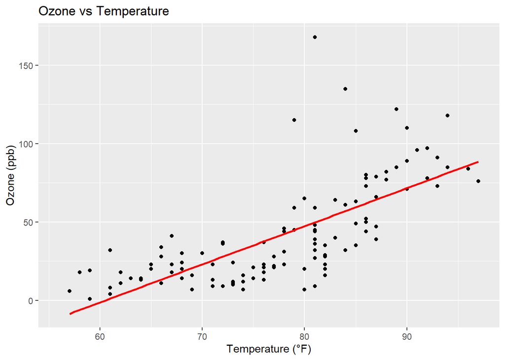

```r
# Plot ozone vs temperature
ggplot(airquality, aes(x = Temp, y = Ozone)) +
  geom_point(na.rm = TRUE) +
  geom_smooth(method = "lm", se = FALSE, color = "red", na.rm = TRUE) +
  labs(title = "Ozone vs Temperature", x = "Temperature (°F)", y = "Ozone (ppb)")
```

## Boxplot: Ozone by Month

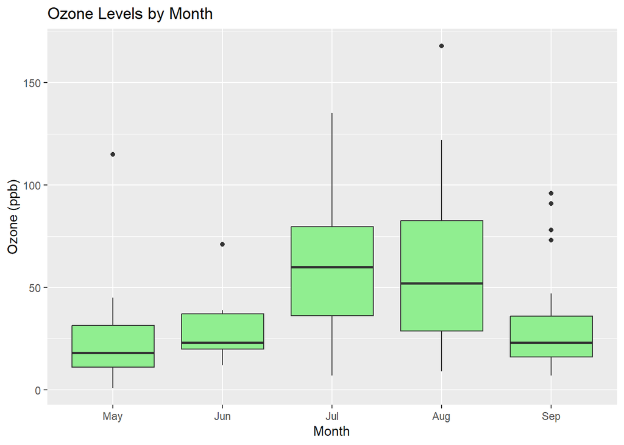

```r
# Boxplot of Ozone levels by Month
ggplot(airquality, aes(x = Month_Factor, y = Ozone)) +
  geom_boxplot(fill = "lightgreen", na.rm = TRUE) +
  labs(title = "Ozone Levels by Month", x = "Month", y = "Ozone (ppb)")
```

## Scatter Plot: Ozone vs Wind

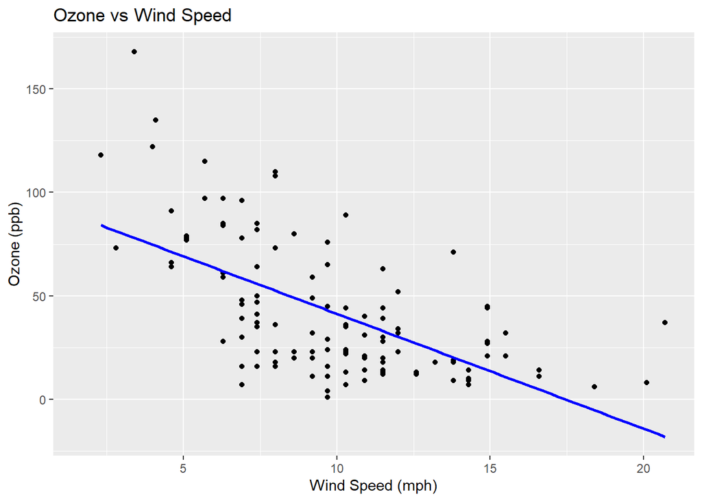

```r
# Ozone vs Wind plot
ggplot(airquality, aes(x = Wind, y = Ozone)) +
  geom_point(na.rm = TRUE) +
  geom_smooth(method = "lm", se = FALSE, color = "blue", na.rm = TRUE) +
  labs(title = "Ozone vs Wind Speed", x = "Wind Speed (mph)", y = "Ozone (ppb)")
```

## Correlation Matrix

```r
# Correlation between numeric variables
cor_matrix <- cor(airquality[, c("Ozone", "Solar.R", "Wind", "Temp")], use = "pairwise.complete.obs")
kable(round(cor_matrix, 2), caption = "Correlation Matrix of Air Quality Variables") %>%
  kable_styling()
```

Correlation Matrix of Air Quality Variables

|  | Ozone | Solar.R | Wind | Temp |
| --- | --- | --- | --- | --- |
| Ozone | 1.00 | 0.35 | -0.60 | 0.70 |
| Solar.R | 0.35 | 1.00 | -0.06 | 0.28 |
| Wind | -0.60 | -0.06 | 1.00 | -0.46 |
| Temp | 0.70 | 0.28 | -0.46 | 1.00 |

# C. Key Insights

- Ozone increases with temperature and decreases with wind speed.
- Seasonal variation shows July–August have higher ozone levels.
- Wind may help disperse ozone and reduce pollution levels.

# D. Ethical and Social Considerations

- Urban areas with higher heat and stagnant wind conditions may face increased health risks.
- Making air quality data public can promote environmental justice and help inform vulnerable communities.
- Visualizations like these can be used in policy decisions to trigger alerts and mitigation efforts.

# E. Conclusion and Recommendations

- Monitor ozone levels during warmer months.
- Improve green infrastructure to counter heat-induced ozone rise.
- Promote wind corridor planning to disperse pollution.

# Appendix: Wireframe Summary

- **Data**: `airquality`
- **Tools**: R, ggplot2, dplyr, RMarkdown
- **Outputs**: Summary stats, plots, interpretation, ethical discussion